# Quantum Technologies Engine: knowledge base

NSF Regional Innovation Engines, Cohort 2. Technology profile v3.1. Draft, in progress

**NSF Quantum Technologies Engine in Connecticut (QuantumCT)**, led by University of Connecticut. NSF award 2531869, start August 2026. Search window for papers and patents: from August 2021 (five years before the award) onward.

## At a glance

| Measure | Value |
| --- | --- |
| People named by NSF or the Engine’s site | 30 |
| of them active researchers (>= 5 works since window start) | 2 |
| Team members who are inventors (2021-2025 grants, in the region) | 0 |
| Partners (site list + team members’ organisations) | 10 |
| Knowledge-producer partners (universities, labs, institutes) | 4 |
| Partner papers in the Engine’s topics | 728 |
| of them with an in-region partner | 727 |
| Regional patents in the technology profile (2021-2025 grants) | 428 |
| Location quotient of the technology profile (patents) | 0.9 |
| Share of regional technology patents owned by partners | 4.7% |

## Economic base

| NAICS | Industry | Employment in region | Establishments | Share of US employment | Employment LQ |
| --- | --- | --- | --- | --- | --- |
| 3344 | Semiconductor and other electronic components | 3,215 | 70 | 1.2% | 1.05 |
| 3345 | Navigational, measuring, electromedical and control instruments | 8,878 | 116 | 2.1% | 1.95 |
| 5417 | Scientific research and development services | 14,782 | 296 | 1.5% | 1.34 |

Industries related to the Engine’s technology (chosen from the NSF abstract, see `data/manual/engine_naics.csv`). County Business Patterns 2023; LQ = the industry’s share of regional employment relative to its share of US employment (1 = US average). Region: whole state(s).

## Technology profile

Version 3.1, core. The NSF abstract names 4 technologies of this Engine (scientific and technical fragments extracted with a fixed prompt; the extraction was done by hand in a chat session, not reproducible). For each technology, all 4,516 OpenAlex topics and all CPC main groups are ranked by several independent signals; the core keeps up to 2 topics and 2 CPC main groups per technology. *Judge*: chosen by a rubric judge where no candidate was confirmed by two kinds of evidence (also by hand in a chat session). An empty cell: no suitable item among the candidates. See Methodology and the comparison of versions.

| # | Technology | OpenAlex topics | CPC main groups |
| --- | --- | --- | --- |
| 1 | quantum information science and technologies | T10020 Quantum Information and Cryptography T10622 Quantum Mechanics and Applications | G06N10/00 Quantum computing, i.e. information processing based on quantum-mechanical phenomena |
| 2 | quantum communications | T10020 Quantum Information and Cryptography T10622 Quantum Mechanics and Applications | H04B10/00 Transmission systems employing electromagnetic waves other than radio-waves, e.g. infrared, visible or ultraviolet light, or employing corpuscular radiation, e.g. quantum communication (judg… |
| 3 | quantum sensing | T10020 Quantum Information and Cryptography | B82Y20/00 Nanooptics, e.g. quantum optics or photonic crystals (judge) |
| 4 | quantum computing | T10682 Quantum Computing Algorithms and Architecture T10020 Quantum Information and Cryptography | G06N10/00 Quantum computing, i.e. information processing based on quantum-mechanical phenomena |

## People

| Role | People |
| --- | --- |
| organizer | 26 |
| research_admin | 3 |
| corporate_rd | 1 |

| Name | Role | On NSF award | Title | Organisation | Works since window (in Engine topics) | h-index | Patents 2021-25 (in Engine profile) | Site | OpenAlex |
| --- | --- | --- | --- | --- | --- | --- | --- | --- | --- |
| Christine Broadbridge | research_admin | Co-PI | Executive Director, Research and Innovation; Founding Dir… | Southern Connecticut State University… | 20 (0) | 14 |  | [page](https://www.quantumct.org/about-quantumct/) | [profile](https://openalex.org/A5070933299) |
| Michael Crair | research_admin | Co-PI | Chairman, Board of Directors; Vice Provost for Research | Yale University | 10 (0) | 49 |  | [page](https://www.quantumct.org/about-quantumct/) | [profile](https://openalex.org/A5073499106) |
| Pamir Alpay | research_admin | PI | Secretary, Board of Directors; Interim Provost and Execut… | University of Connecticut | 3 (0) | 2 |  | [page](https://www.quantumct.org/about-quantumct/) | [profile](https://openalex.org/A5021054110) |
| Andreas Roelofs | corporate_rd |  | Vice President; Research and Development Director | RTX Research Center | - | - |  | [page](https://www.quantumct.org/about-quantumct/) |  |
| Abhijit Banerjee | organizer |  |  | University of Connecticut | - | - |  | [page](https://www.quantumct.org/about-quantumct/) |  |
| Alison Malloy | organizer | Co-PI |  | Connecticut Innovations | - | - |  | [page](https://www.quantumct.org/about-quantumct/) |  |
| Amit Savkar | organizer |  |  | University of Connecticut | 1 (0) | 3 |  | [page](https://www.quantumct.org/about-quantumct/) | [profile](https://openalex.org/A5045305558) |
| Anna Galjan | organizer |  |  | University of Connecticut | - | - |  | [page](https://www.quantumct.org/about-quantumct/) |  |
| Bethany Javidi | organizer |  |  | University of Connecticut | 0 | 1 |  | [page](https://www.quantumct.org/about-quantumct/) | [profile](https://openalex.org/A5052140519) |
| Bianca Montrosse-Moorehead | organizer |  |  | University of Connecticut | - | - |  | [page](https://www.quantumct.org/about-quantumct/) |  |
| Brianna Demers | organizer |  |  | University of Connecticut | - | - |  | [page](https://www.quantumct.org/about-quantumct/) |  |
| Cansu Kaya Yavas | organizer |  |  | University of Connecticut | - | - |  | [page](https://www.quantumct.org/about-quantumct/) |  |
| Caroline Dealy | organizer |  |  | University of Connecticut | 3 (0) | 23 |  | [page](https://www.quantumct.org/about-quantumct/) | [profile](https://openalex.org/A5037714057) |
| Claudia Reuter | organizer |  |  | Yale Ventures | - | - |  | [page](https://www.quantumct.org/about-quantumct/) |  |
| Daniel O’Keefe | organizer |  | Commissioner, Department of Economic and Community Develo… | State of Connecticut | - | - |  | [page](https://www.quantumct.org/about-quantumct/) |  |
| Erik Clemons | organizer | Co-PI |  | ConnCORP | - | - |  | [page](https://www.quantumct.org/about-quantumct/) |  |
| Esme Lombard | organizer |  | Director, External Affairs | QuantumCT | - | - |  | [page](https://www.quantumct.org/about-quantumct/) |  |
| Florian Carle | organizer |  |  | Yale Quantum Institute | - | - |  | [page](https://www.quantumct.org/about-quantumct/) |  |
| Kathy Lynch | organizer |  |  | Yale Ventures | - | - |  | [page](https://www.quantumct.org/about-quantumct/) |  |
| Kimberly Bradley | organizer |  |  | Yale University | - | - |  | [page](https://www.quantumct.org/about-quantumct/) |  |
| Kirti Patel | organizer |  | Deputy Commissioner, Department of Economic and Community… | State of Connecticut | - | - |  | [page](https://www.quantumct.org/about-quantumct/) |  |
| Matthew Mroz | organizer |  |  | University of Connecticut | - | - |  | [page](https://www.quantumct.org/about-quantumct/) |  |
| Michael DiDonato | organizer |  |  | University of Connecticut | - | - |  | [page](https://www.quantumct.org/about-quantumct/) |  |
| Monica Roy | organizer |  | Senior Director, Corporate Engagement | QuantumCT | - | - |  | [page](https://www.quantumct.org/about-quantumct/) |  |
| Monica Vella-Angelastro | organizer |  |  | Yale University | - | - |  | [page](https://www.quantumct.org/about-quantumct/) |  |
| Natasha Harris | organizer |  | Workforce Development Manager | QuantumCT | - | - |  | [page](https://www.quantumct.org/about-quantumct/) |  |
| Nicole Barkley | organizer |  | Operations Manager | QuantumCT | - | - |  | [page](https://www.quantumct.org/about-quantumct/) |  |
| Rich Jacob | organizer |  |  | Yale University | - | - |  | [page](https://www.quantumct.org/about-quantumct/) |  |
| Saranda Belica | organizer |  |  | University of Connecticut | - | - |  | [page](https://www.quantumct.org/about-quantumct/) |  |
| Vivek Ramakrishnan | organizer |  | Senior Director, Tech Deployment & Interim CEO | QuantumCT | - | - |  | [page](https://www.quantumct.org/about-quantumct/) |  |

Publication counts are shown only where the OpenAlex author matches both the name and the person’s current organisation. The OpenAlex link is given only for these reliable matches, and not for profiles flagged as possibly merging several namesakes. *Site* links to the page of the Engine’s website where the person is named. Click a number of works to see the list on the Publications page. *Patents*: US grants 2021-2025 with the person among the inventors (same last and first name, address in the Engine’s states); click the number for the list on the Patents page. In brackets: works in the Engine’s topics, patents with a CPC code in the Engine’s technology profile.

## Researchers at partner organisations

| # | Researcher | Partner | Works in the Engine’s topics | Citations | Years | Most cited of these works |
| --- | --- | --- | --- | --- | --- | --- |
| 1 | [Aleksander Kubica](https://openalex.org/A5015670643) | Yale University | 52 | 1002 | 2025-2026 | [Hardware-efficient quantum error correction via concatena…](https://openalex.org/W4407957966) |
| 2 | [Víctor S. Batista](https://openalex.org/A5089129603) | Yale University | 44 | 929 | 2021-2026 | [Quantum Machine Learning in Drug Discovery: Applications …](https://openalex.org/W4411084656) |
| 3 | [Yongshan Ding](https://openalex.org/A5012944782) | Yale University | 43 | 1328 | 2021-2026 | [QuantumNAS: Noise-Adaptive Search for Robust Quantum Circ…](https://openalex.org/W3186461170) |
| 4 | [S. M. Girvin](https://openalex.org/A5046083937) | Yale University | 42 | 3204 | 2021-2026 | [Real-time quantum error correction beyond break-even](https://openalex.org/W4353055437) |
| 5 | [Rodrigo G. Cortiñas](https://openalex.org/A5032260005) | Yale University | 41 | 589 | 2023-2026 | [Observation of Pairwise Level Degeneracies and the Quantu…](https://openalex.org/W4402189576) |
| 6 | [Shruti Puri](https://openalex.org/A5024414185) | Yale University | 38 | 2181 | 2021-2026 | [High-fidelity gates and mid-circuit erasure conversion in…](https://openalex.org/W4387517741) |
| 7 | [Walter O. Krawec](https://openalex.org/A5024539968) | University of Connecticut | 35 | 312 | 2021-2026 | [Quantum Networks for Resilient Power Grids: Theory and Si…](https://openalex.org/W4285145494) |
| 8 | [Michel Devoret](https://openalex.org/A5089631322) | Yale University | 32 | 2938 | 2021-2026 | [Real-time quantum error correction beyond break-even](https://openalex.org/W4353055437) |
| 9 | [Robert J. Schoelkopf](https://openalex.org/A5084929692) | Yale University | 29 | 2515 | 2021-2026 | [Real-time quantum error correction beyond break-even](https://openalex.org/W4353055437) |
| 10 | [Luigi Frunzio](https://openalex.org/A5083803230) | Yale University | 28 | 2240 | 2021-2026 | [Real-time quantum error correction beyond break-even](https://openalex.org/W4353055437) |
| 11 | [Jakub M. Szefer](https://openalex.org/A5044387689) | Yale University | 27 | 542 | 2021-2025 | [Exploration of Power Side-Channel Vulnerabilities in Quan…](https://openalex.org/W4388857017) |
| 12 | [Hong X. Tang](https://openalex.org/A5056757543) | Yale University | 25 | 1158 | 2021-2026 | [2022 Roadmap on integrated quantum photonics](https://openalex.org/W3128101795) |
| 13 | [Chuanqi Xu](https://openalex.org/A5101523308) | Yale University | 20 | 424 | 2022-2025 | [Exploration of Power Side-Channel Vulnerabilities in Quan…](https://openalex.org/W4388857017) |
| 14 | [Léa Ferreira dos Santos](https://openalex.org/A5085734763) | University of Connecticut | 20 | 414 | 2023-2026 | [Spectral kissing and its dynamical consequences in the sq…](https://openalex.org/W4385334593) |
| 15 | [Ilya Drozdov](https://openalex.org/A5049482374) | University of Connecticut | 15 | 3859 | 2023-2026 | [Quantum error correction below the surface code threshold](https://openalex.org/W4405183524) |

The grant names mostly managers; the technology is often developed at the partner universities and labs. These are the authors with the most works in the Engine’s OpenAlex topics written at a knowledge-producer partner in the Engine’s states, since the window start (at least 3 works; top 15). The list depends on the technology profile version. OpenAlex sometimes merges namesakes into one author: check the profile before relying on a name.

## Partners

| Organisation class | Partners |
| --- | --- |
| company | 3 |
| university | 3 |
| government | 1 |
| intermediary | 1 |
| investor | 1 |
| research_institute | 1 |

Partner list on the site: *Not available: no partner list; organisations of board and planning committee members are used instead*.

| Partner | Class | State | OpenAlex works since window (all topics) |
| --- | --- | --- | --- |
| Yale University | university | Connecticut | 115507 |
| University of Connecticut | university | Connecticut | 45122 |
| Southern Connecticut State University | university | Connecticut | 1481 |
| RTX Research Center | research_institute |  | NA |

## Science base: partner papers in the Engine’s topics

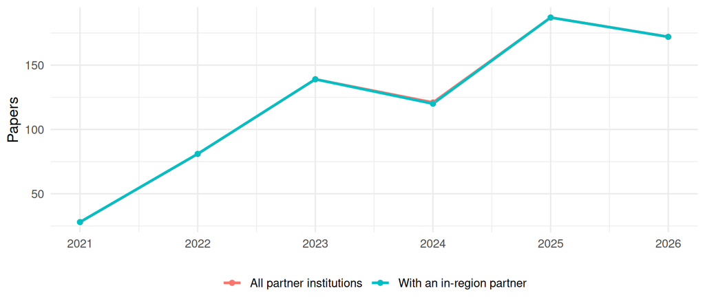

| Partner | Papers in topics |
| --- | --- |
| Yale University | 573 |
| University of Connecticut | 172 |

## Technology base: patents

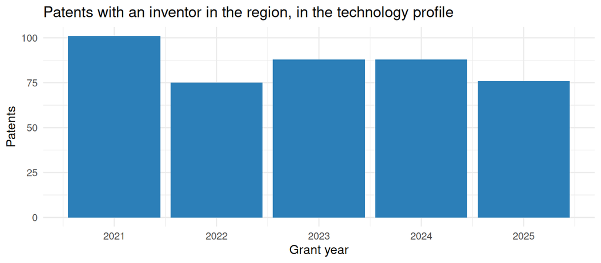

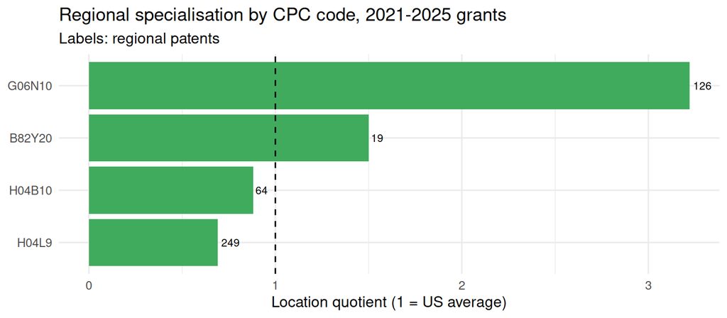

| Assignee | Regional patents in profile |
| --- | --- |
| International Business Machines Corporation | 103 |
| INTERNATIONAL BUSINESS MACHINES CORPORATION | 28 |
| MASTERCARD INTERNATIONAL INCORPORATED | 28 |
| Yale University | 20 |
| ARRIS Enterprises LLC | 19 |
| Amazon Technologies, Inc. | 10 |
| Citibank, N.A. | 10 |
| IonQ, Inc. | 9 |
| PROTEGRITY CORPORATION | 8 |
| ACCENTURE GLOBAL SOLUTIONS LIMITED | 7 |

Partner-owned patents invented in the region: 442, of which 20 (4.5%) fall in the Engine’s technology profile.

## Competition

With 428 patents in the technology profile (2021-2025 grants), the Engine’s region would rank **17** among US states; its specialisation (LQ) is 0.897.

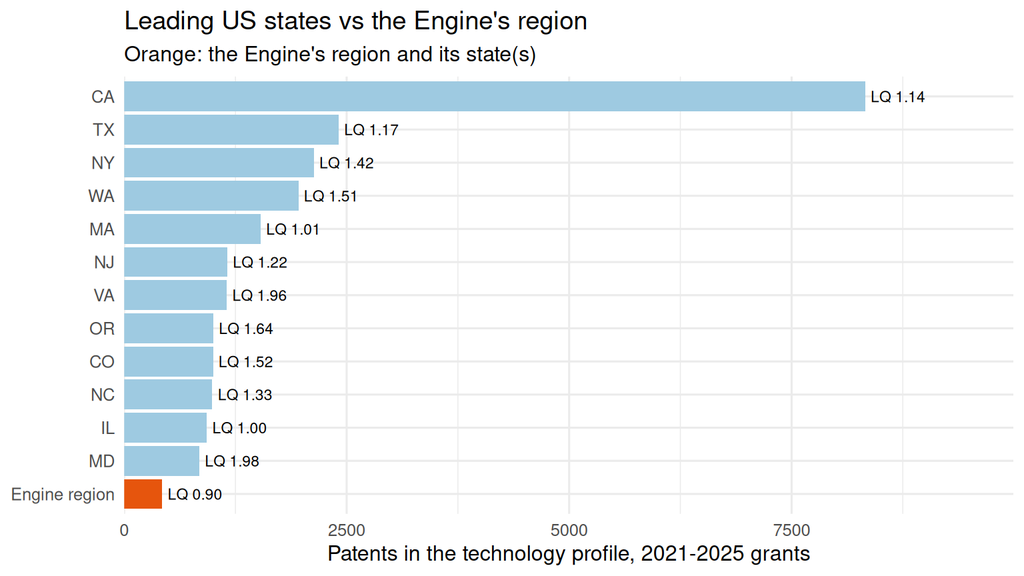

| Country | Share of US patents in profile | Share of world papers in topics |
| --- | --- | --- |
| US | 57.2% | 17.0% |
| CN | 8.7% | 14.6% |
| JP | 6.9% | 4.2% |
| GB | 5.1% | 4.9% |
| IN | 4.6% | 6.6% |
| CA | 4.5% | 3.0% |
| DE | 4.0% | 6.7% |
| KR | 4.0% | 1.8% |
| IL | 3.0% | NA |
| FR | 2.5% | 3.6% |

Patents: inventor countries on US grants in the profile (a patent counts for every country of its inventors). Papers: author countries of OpenAlex works in the Engine’s topics since the window start.

## Data and limitations

- People: PIs and Co-PIs from the NSF Award API; leadership listed on the Engine’s website. Roles come from titles and organisations, revised with OpenAlex evidence.
- Partners: as listed on the Engine’s website, plus organisations of team members. Some Engines publish partner logos without names.
- Region: the Engine’s counties where the list is known (NEO-SMART: 18 Northeast Ohio counties; STELLAR: 11 counties from the NSF abstract), otherwise its states (state-level proxy).
- Technology profile: v3.1 (switch versions in the header). Partner papers and regional patents depend on it: v1 uses mostly CPC subclasses, the v3.1 core uses CPC main groups, which are narrower, so it counts fewer patents and the LQ of a small region rests on few patents.
- Papers: OpenAlex; partner papers are restricted to the Engine’s OpenAlex topics.
- Patents: USPTO grants 2021-2025; inventor locations from PatentsView; pre-grant publications are not included.